# Data Visualization I

Lab 2

Dr. Irene Vrbik

In this lab, we will go through the plots created in Lectures [3](https://irene.quarto.pub/data-visualization/lecture3.html#/title-slide) and [4](https://irene.quarto.pub/data-visualization/lecture4.html#/title-slide), this time, using `ggplot` in R. The corresponding Altair code can be found within the lecture slide decks.

First and foremost let’s load the necessary packages. Obviously, we’ll need **ggplot2** but as seen below, this is automatically loaded alongside the **tidyverse** library (which will be used data wrangling).

```r
library(tidyverse)
```

## Data sets

### Weather Data Set

Today we will be visualizing weather statistics for the U.S. cities of Seattle and New York.

```r
weather = 'https://cdn.jsdelivr.net/npm/vega-datasets@1/data/weather.csv'
df = read_csv(weather)
```

A nice feature of using **readr**’s `read_csv` function (as opposed to using `read.csv` in base R) is that it automatically returns the data types of the columns in our data frame. Another handy function to help inspect our data frame is `glimpse()` from the **dplyr** package (similar to `.info()` in Python). N.B. all the packages mentioned are loaded automatically when we load `tidyverse` package.

```r
df %>% glimpse()
```

```
## Rows: 2,922
## Columns: 7
## $ location      <chr> "Seattle", "Seattle", "Seattle", "Seattle", "Seattle", "…
## $ date          <date> 2012-01-01, 2012-01-02, 2012-01-03, 2012-01-04, 2012-01…
## $ precipitation <dbl> 0.0, 10.9, 0.8, 20.3, 1.3, 2.5, 0.0, 0.0, 4.3, 1.0, 0.0,…
## $ temp_max      <dbl> 12.8, 10.6, 11.7, 12.2, 8.9, 4.4, 7.2, 10.0, 9.4, 6.1, 6…
## $ temp_min      <dbl> 5.0, 2.8, 7.2, 5.6, 2.8, 2.2, 2.8, 2.8, 5.0, 0.6, -1.1, …
## $ wind          <dbl> 4.7, 4.5, 2.3, 4.7, 6.1, 2.2, 2.3, 2.0, 3.4, 3.4, 5.1, 1…
## $ weather       <chr> "drizzle", "rain", "rain", "rain", "rain", "rain", "rain…
```

### Gap Minder

```r
gm_url = 'https://irene.vrbik.ok.ubc.ca/data/world-data-gapminder.csv'
gm = read_csv(gm_url)
gm2018 = gm %>% filter(between(year, as.Date('2018-01-01'), as.Date('2018-12-31')))
glimpse(gm2018)
```

```
## Rows: 178
## Columns: 14
## $ country               <chr> "Afghanistan", "Albania", "Algeria", "Angola", "…
## $ year                  <date> 2018-01-01, 2018-01-01, 2018-01-01, 2018-01-01,…
## $ population            <dbl> 3.64e+07, 2.93e+06, 4.20e+07, 3.08e+07, 1.03e+05…
## $ region                <chr> "Asia", "Europe", "Africa", "Africa", "Americas"…
## $ sub_region            <chr> "Southern Asia", "Southern Europe", "Northern Af…
## $ income_group          <chr> "Low", "Upper middle", "Upper middle", "Lower mi…
## $ life_expectancy       <dbl> 58.7, 78.0, 77.9, 65.2, 77.6, 77.0, 76.0, 82.9, …
## $ income                <dbl> 1870, 12400, 13700, 5850, 21000, 18900, 8660, 45…
## $ children_per_woman    <dbl> 4.33, 1.71, 2.64, 5.55, 2.03, 2.26, 1.60, 1.83, …
## $ child_mortality       <dbl> 65.90, 12.90, 23.10, 81.60, 7.89, 10.60, 12.90, …
## $ pop_density           <dbl> 55.70, 107.00, 17.60, 24.70, 234.00, 16.30, 103.…
## $ co2_per_capita        <dbl> NA, NA, NA, NA, NA, NA, NA, NA, NA, NA, NA, NA, …
## $ years_in_school_men   <dbl> NA, NA, NA, NA, NA, NA, NA, NA, NA, NA, NA, NA, …
## $ years_in_school_women <dbl> NA, NA, NA, NA, NA, NA, NA, NA, NA, NA, NA, NA, …
```

## (Re)creation of plots from Lecture 3

### Layered Plot

We will attempt to recreate this plot:

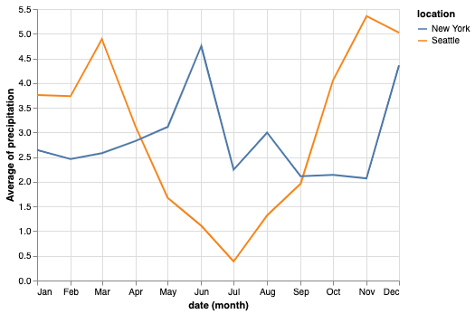

Recall the Altair code:

```python
# code in Python's Altair (not run in R)
precip = alt.Chart(df).mark_line(
).encode(
  x = 'month(date)',            # will bin obs by month
  y = 'average(precipitation)', # will avg prec within in month
  color = 'location')
```

To bin the data according to month, I have found the easiest way is to create a new data column which extracts this information from dates. The **lubridate** library then converts this to an ordinal categorical variable. To create this in R we need to make use of the `stat_summary` as used in lab 1. As a final step we need to use `group` aesthetic (read documentation [here](https://ggplot2.tidyverse.org/reference/aes_group_order.html))

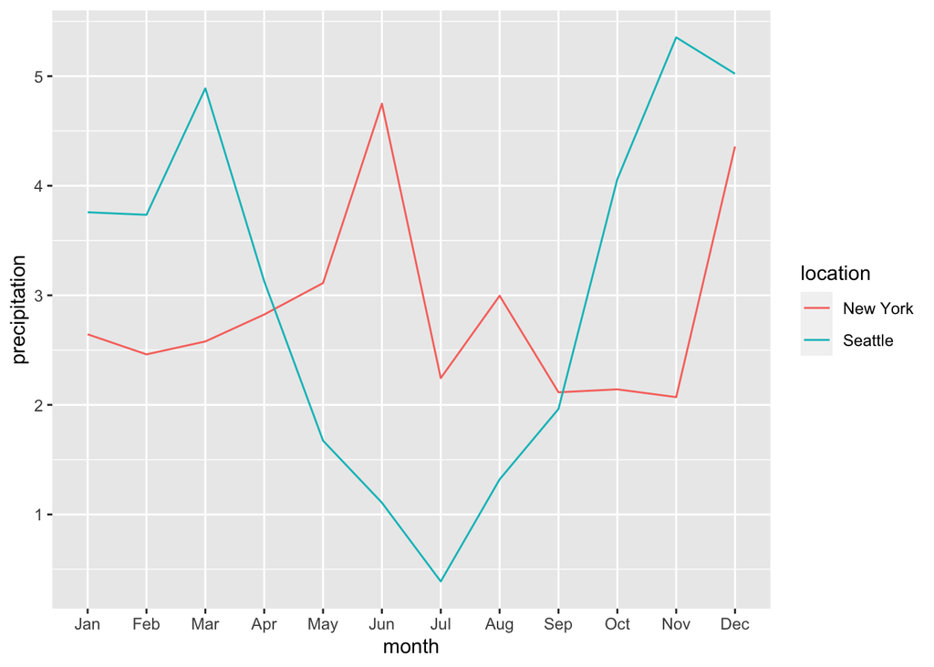

```r
library(lubridate)
df$month =  month(df$date, label=TRUE, abbr=TRUE)

ggplot(df, aes(x = month, y = precipitation, color = location, group = location)) +
  stat_summary(fun = mean, geom = "line")
```

### Line Plots

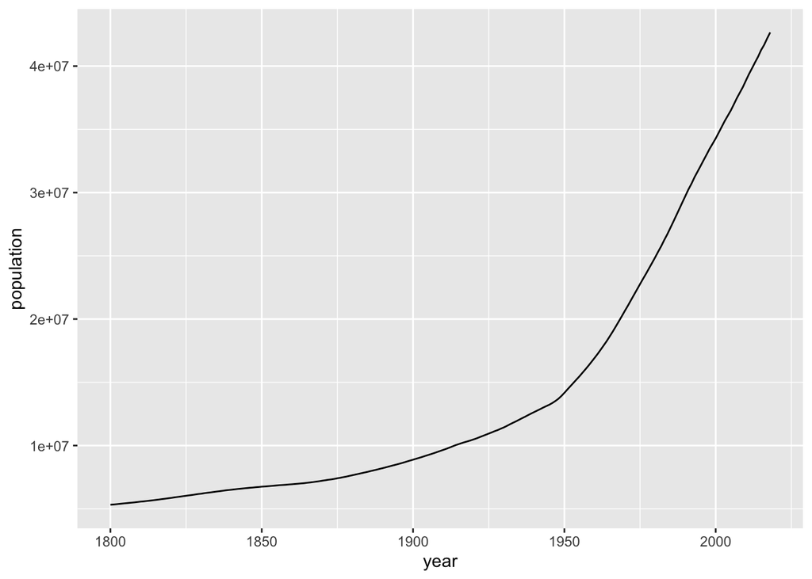

```r
ggplot(gm, aes(x = year, y = population)) +
  geom_line(stat = "summary", fun = mean)
```

### Area Plots

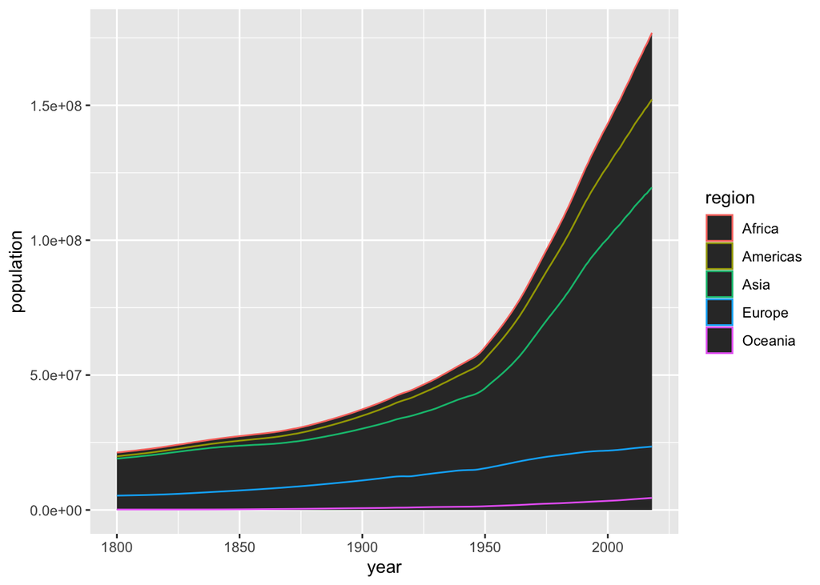

```r
ggplot(gm, aes(x = year, y = population, colour = region)) +
  geom_area(stat = "summary", fun = mean)
```

Note that colour corsponds to the line dividing the stacked area chart, rather than the fill of the area. So to fix that we replace `color` by `fill`:

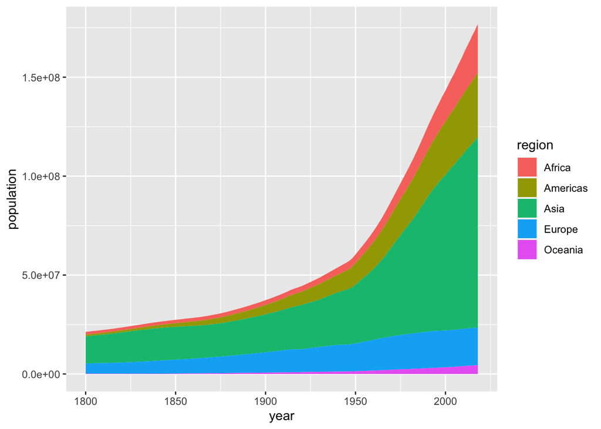

```r
ggplot(gm, aes(x = year, y = population, fill = region)) +
  geom_area(stat = "summary", fun = mean)
```

### Bar Plots

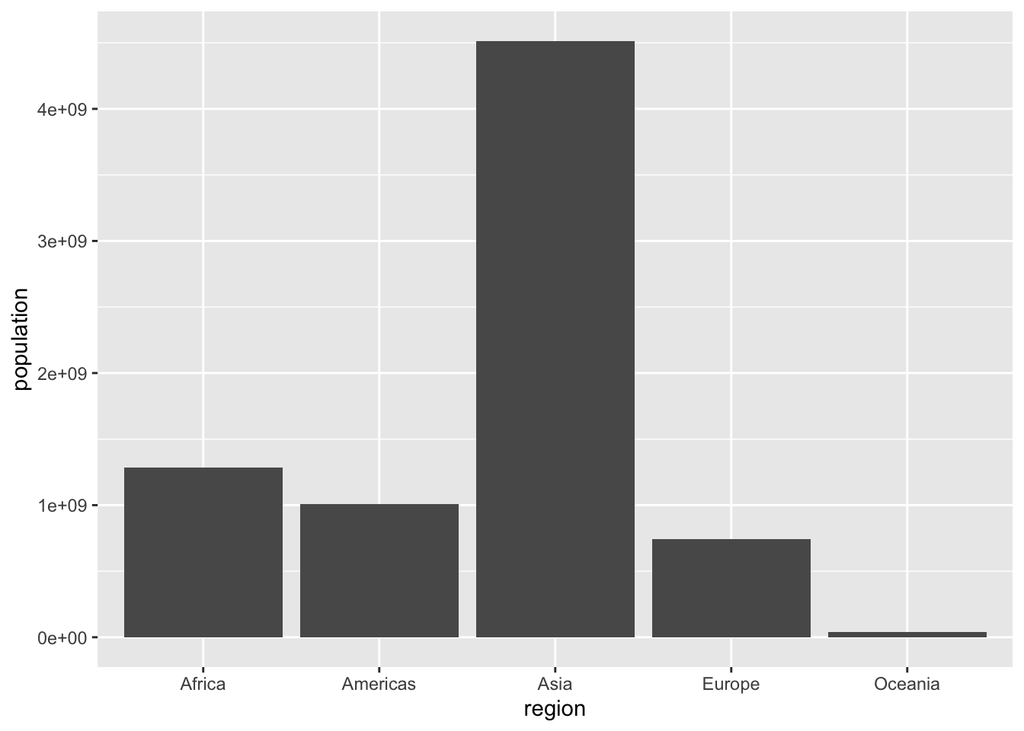

```r
ggplot(gm2018, aes(x=region,  y= population)) +
  geom_bar(stat = "summary", fun = sum)
```

To get a count rather than a sum of the population we use the `stat_count` function (or `stat = "count"` in the geom function). Be sure to remove the y aes or you will get an error!

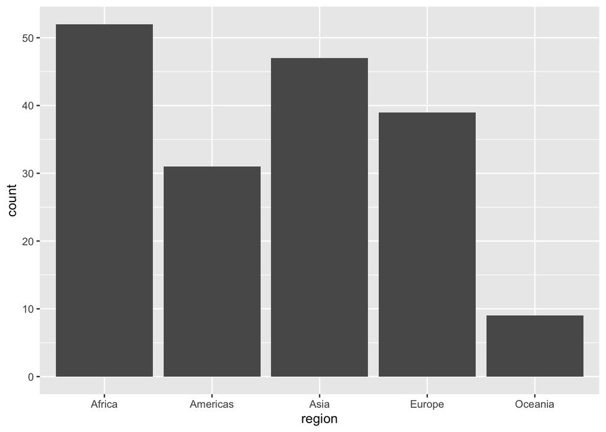

```r
ggplot(gm2018, aes(x=region)) +
  geom_bar(stat = "count") #/ stat_count(geom = "bar")
```

Note that this is acutally the default stat for `geom_bar`:

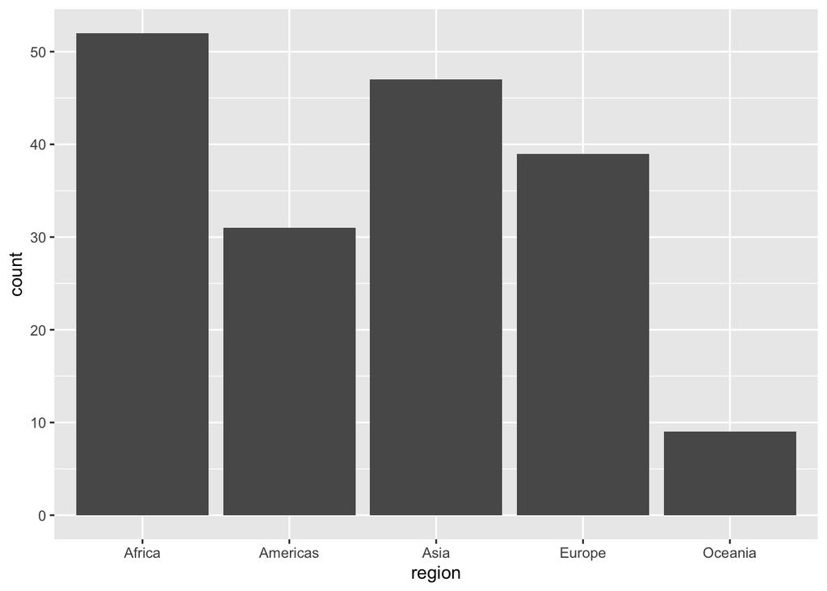

```r
ggplot(gm2018, aes(x=region)) +
  geom_bar()
```

```r
gm2018 = gm2018 %>%
  group_by(region) %>%
  add_count() # creates a column called 'n' that holds the total count for each region
head(gm2018)
```

| country | year | population | region | sub_region | income_group | life_expectancy | income | children_per_woman | child_mortality | pop_density | co2_per_capita | years_in_school_men | years_in_school_women | n |
| --- | --- | --- | --- | --- | --- | --- | --- | --- | --- | --- | --- | --- | --- | --- |
| Afghanistan | 2018-01-01 | 36400000 | Asia | Southern Asia | Low | 58.7 | 1870 | 4.33 | 65.90 | 55.7 | NA | NA | NA | 47 |
| Albania | 2018-01-01 | 2930000 | Europe | Southern Europe | Upper middle | 78.0 | 12400 | 1.71 | 12.90 | 107.0 | NA | NA | NA | 39 |
| Algeria | 2018-01-01 | 42000000 | Africa | Northern Africa | Upper middle | 77.9 | 13700 | 2.64 | 23.10 | 17.6 | NA | NA | NA | 52 |
| Angola | 2018-01-01 | 30800000 | Africa | Sub-Saharan Africa | Lower middle | 65.2 | 5850 | 5.55 | 81.60 | 24.7 | NA | NA | NA | 52 |
| Antigua and Barbuda | 2018-01-01 | 103000 | Americas | Latin America and the Caribbean | High | 77.6 | 21000 | 2.03 | 7.89 | 234.0 | NA | NA | NA | 31 |
| Argentina | 2018-01-01 | 44700000 | Americas | Latin America and the Caribbean | High | 77.0 | 18900 | 2.26 | 10.60 | 16.3 | NA | NA | NA | 31 |

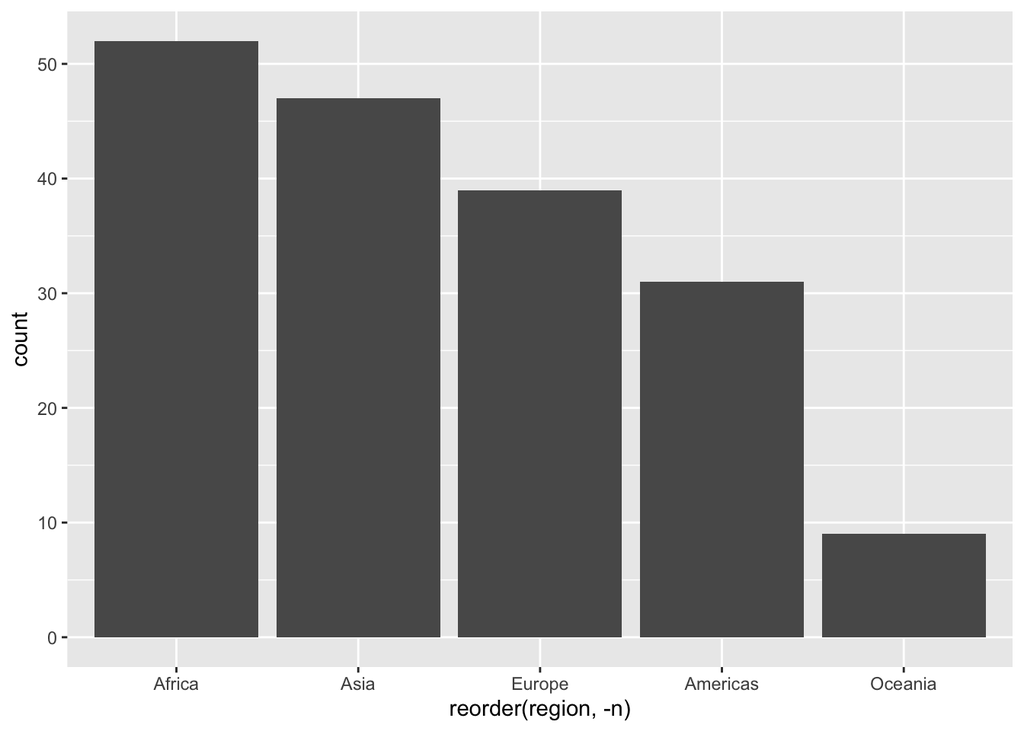

```r
ggplot(gm2018, aes(x=reorder(region, -n))) +
  geom_bar(stat = "count")
```

Note that we use `-n` to indicate that want to sort in decreasing order (as opposed to using `n` which would sort in increasing order).

### Histograms

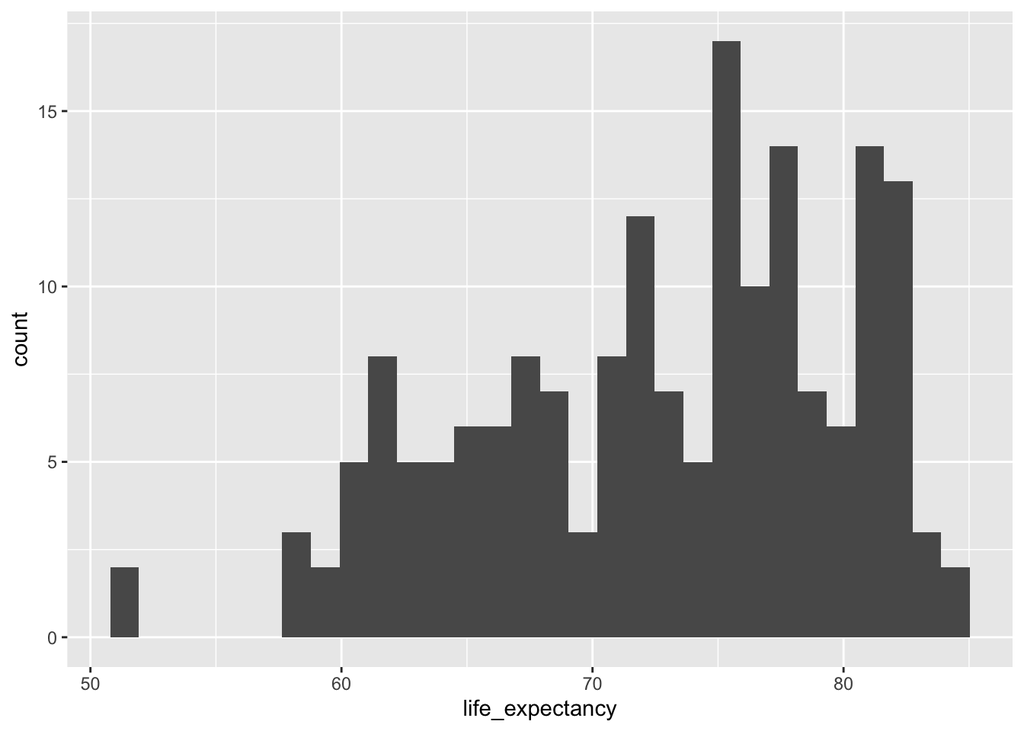

```r
ggplot(gm2018, aes(x = life_expectancy)) +
  geom_bar(stat = "bin")
```

In ggplot we can specify the `binwidth` (as opposed to the number of maxbins we set in Altair). For example:

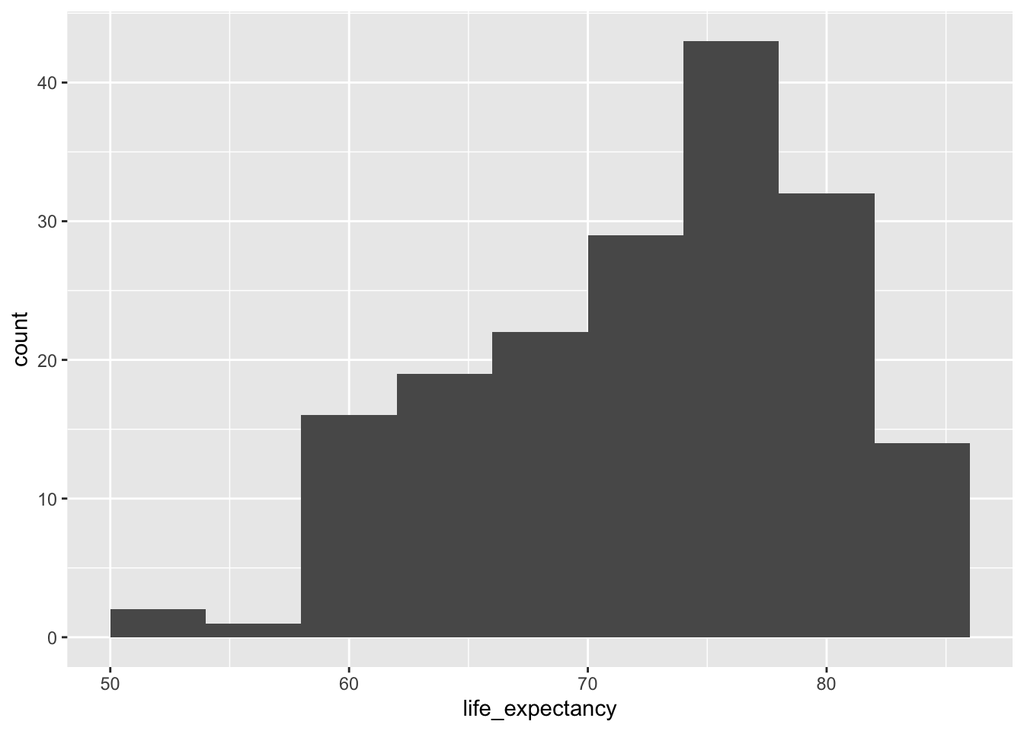

```r
ggplot(gm2018, aes(x = life_expectancy)) +
  geom_bar(stat = "bin", binwidth = 4)
```